# Loading and preprocessing the data

## Loading and preprocessing the data

#### Load the Data

Read in the data from the file 'activity.csv'.

```r
#read the data in directly from a .csv file
inData <- read.csv("activity.csv")
```

## What is mean total number of steps taken per day?

#### Calculate the total number of steps taken per day

Compute the daily count of total number of steps taken, ignoring NA values.

Split the step data into subsets by the date and sum the steps taken each day.

```r
#we will need to process the data slightly to make the computations easier
dailySteps <- aggregate(inData$steps,list(inData$date),FUN=sum,na.rm=TRUE)
library(ggplot2)
```

#### Calcluate and report the mean and median of the total number of steps taken per day.

Compute the mean and median values of the daily step count and create the histogram plot of the data.

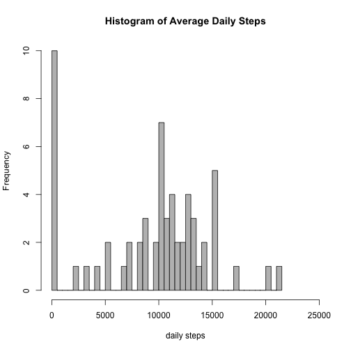

```r
#compute the mean and median values
meanDailySteps = mean(dailySteps$x)
medianDailySteps = median(dailySteps$x)
hist(dailySteps$x,breaks=50,freq=TRUE,col="gray",main="Histogram of Average Daily Steps",xlab="daily steps",xlim=c(0,25000))
```

- Mean number of steps taken each day = 9354.23
- Median number of steps taken each day = 10395

## What is the average daily activity pattern?

#### Make a time series plot of the 5-minute interval and the average number of steps taken, averaged across all days.

Split the data by steps taken per each 5 minute interval and average the interval steps over all days.

Create a times series plot of the data.

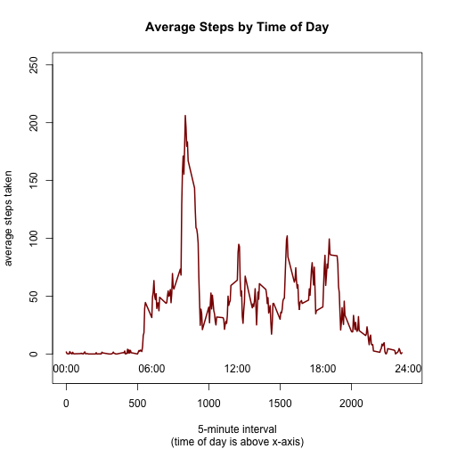

```r
#process the data slightly before processing/creating the histogram; plot the data; and add some annotations
intSteps <- aggregate(inData$steps,list(inData$interval),FUN=mean,na.rm=TRUE)
plot(intSteps,type='l',col='dark red',xlab='5-minute interval',ylab='average steps taken',xlim=c(0,2400), ylim=c(-15,250), main="Average Steps by Time of Day", lwd=c(2), sub="(time of day is above x-axis)")
text(0,-12,"00:00")
text(600,-12,"06:00")
text(1200,-12,"12:00")
text(1800,-12,"18:00")
text(2400,-12,"24:00")
```

#### Which 5-minute interval, on average across all the days in the dataset, contains the maximum number of steps?

Determine the interval which has the maximum number of steps (on average) over all dates.

```r
#compute the 5 minute interval with the max steps, on average
maxInterval <- intSteps$Group.1[[which.max(intSteps$x)]]
```

- Time of maximum steps taken in a five minute interval (on average) = 835